# 17_pick_wave_pams3

## 17_pick_wave_pams3

#### Question

1. A [mass-spring system](https://en.wikipedia.org/wiki/Simple_harmonic_motion#Examples) oscillates over time. The position (in meters) of the mass is plotted as a function of time (in seconds).

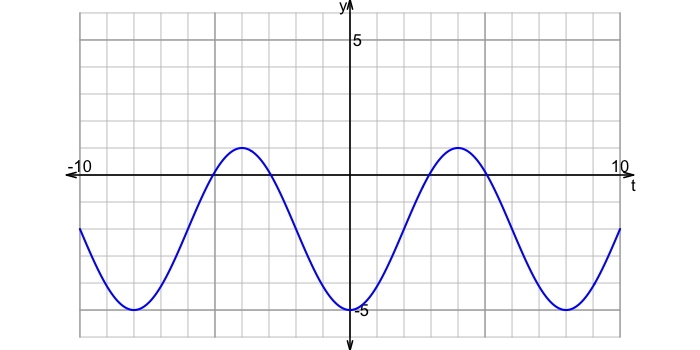

   Choose a trigonometric function ($g$), and the parameters ($A$, $P$, and $D$), to model this oscillatory motion.

   $$y~=~A\cdot g\left(\frac{2\pi}{P}t\right)+D$$
   - $g=$
   - $A=$
   - $P=$
   - $D=$

#### Question

2. A [mass-spring system](https://en.wikipedia.org/wiki/Simple_harmonic_motion#Examples) oscillates over time. The position (in meters) of the mass is plotted as a function of time (in seconds).

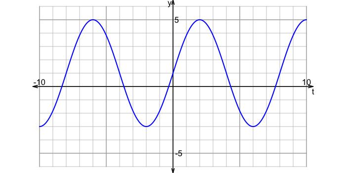

   Choose a trigonometric function ($g$), and the parameters ($A$, $P$, and $D$), to model this oscillatory motion.

   $$y~=~A\cdot g\left(\frac{2\pi}{P}t\right)+D$$
   - $g=$
   - $A=$
   - $P=$
   - $D=$

#### Question

3. A [mass-spring system](https://en.wikipedia.org/wiki/Simple_harmonic_motion#Examples) oscillates over time. The position (in meters) of the mass is plotted as a function of time (in seconds).

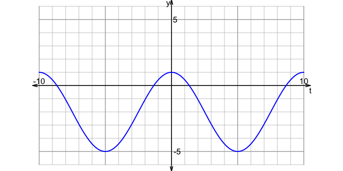

   Choose a trigonometric function ($g$), and the parameters ($A$, $P$, and $D$), to model this oscillatory motion.

   $$y~=~A\cdot g\left(\frac{2\pi}{P}t\right)+D$$
   - $g=$
   - $A=$
   - $P=$
   - $D=$

#### Question

4. A [mass-spring system](https://en.wikipedia.org/wiki/Simple_harmonic_motion#Examples) oscillates over time. The position (in meters) of the mass is plotted as a function of time (in seconds).

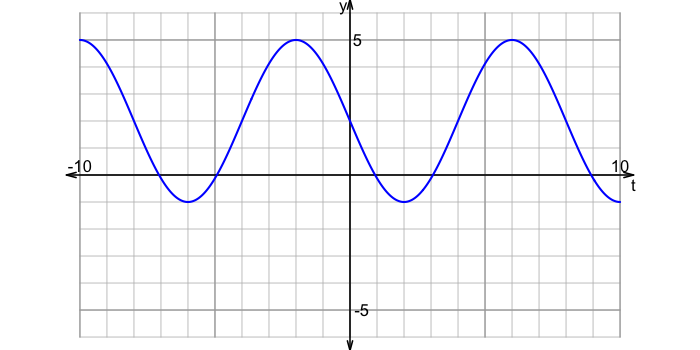

   Choose a trigonometric function ($g$), and the parameters ($A$, $P$, and $D$), to model this oscillatory motion.

   $$y~=~A\cdot g\left(\frac{2\pi}{P}t\right)+D$$
   - $g=$
   - $A=$
   - $P=$
   - $D=$

#### Question

5. A [mass-spring system](https://en.wikipedia.org/wiki/Simple_harmonic_motion#Examples) oscillates over time. The position (in meters) of the mass is plotted as a function of time (in seconds).

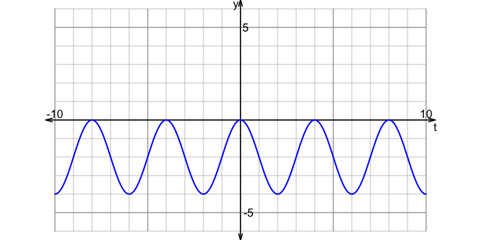

   Choose a trigonometric function ($g$), and the parameters ($A$, $P$, and $D$), to model this oscillatory motion.

   $$y~=~A\cdot g\left(\frac{2\pi}{P}t\right)+D$$
   - $g=$
   - $A=$
   - $P=$
   - $D=$

#### Question

6. A [mass-spring system](https://en.wikipedia.org/wiki/Simple_harmonic_motion#Examples) oscillates over time. The position (in meters) of the mass is plotted as a function of time (in seconds).

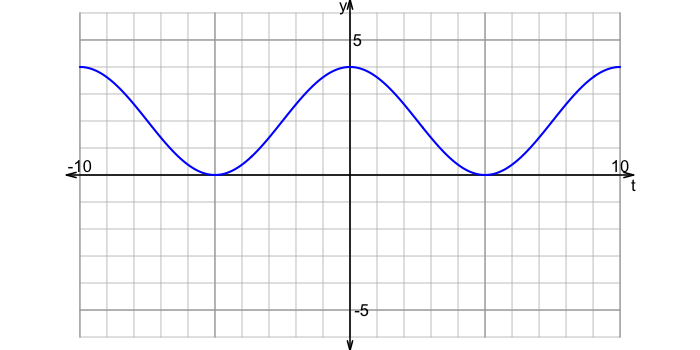

   Choose a trigonometric function ($g$), and the parameters ($A$, $P$, and $D$), to model this oscillatory motion.

   $$y~=~A\cdot g\left(\frac{2\pi}{P}t\right)+D$$
   - $g=$
   - $A=$
   - $P=$
   - $D=$

#### Question

7. A [mass-spring system](https://en.wikipedia.org/wiki/Simple_harmonic_motion#Examples) oscillates over time. The position (in meters) of the mass is plotted as a function of time (in seconds).

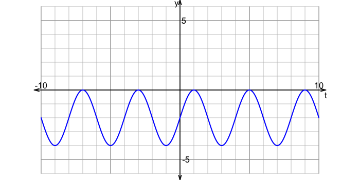

   Choose a trigonometric function ($g$), and the parameters ($A$, $P$, and $D$), to model this oscillatory motion.

   $$y~=~A\cdot g\left(\frac{2\pi}{P}t\right)+D$$
   - $g=$
   - $A=$
   - $P=$
   - $D=$

#### Question

8. A [mass-spring system](https://en.wikipedia.org/wiki/Simple_harmonic_motion#Examples) oscillates over time. The position (in meters) of the mass is plotted as a function of time (in seconds).

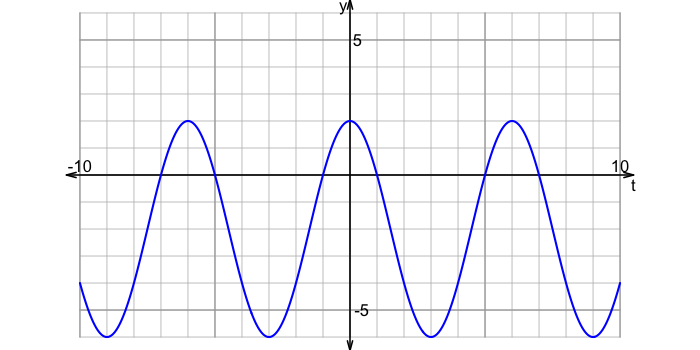

   Choose a trigonometric function ($g$), and the parameters ($A$, $P$, and $D$), to model this oscillatory motion.

   $$y~=~A\cdot g\left(\frac{2\pi}{P}t\right)+D$$
   - $g=$
   - $A=$
   - $P=$
   - $D=$